# Bring Your Own Scores

Vathy M. Kamulete

Last Updated: 2023-02-18

Please see the [paper](https://openreview.net/forum?id=S5UG2BLi9xc) (Kamulete 2022) for details. We denote the R package as `dsos`, to avoid confusion with `D-SOS`, the method.

## DIY

To test for adverse shift, we need two main ingredients: outlier scores from a scoring function and a way to compute a $p-$value (or a Bayes factor). First, the scoring function assigns to a potentially *multivariate* observation a *univariate* score. Second, for $p-$value, we may use permutations. The prefix *pt* stands for permutation test. The function `pt_refit` is a wrapper for this approach, provided we supply a user-defined scoring function. Sample splitting and out-of-bag variants are alternatives to permutations. Both use the asymptotic null distribution and sidestep refitting (recalibrating) the scoring function after every permutation. As a result, they can be appreciably faster than inference based on permutations.

## In Action

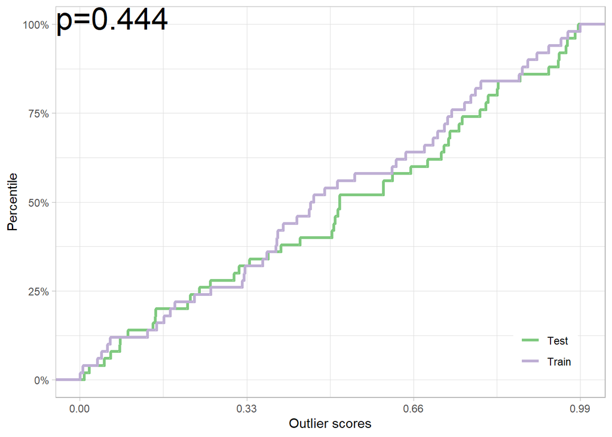

```r
set.seed(12345)
data(iris)
x_train <- iris[1:50, 1:4] # Training sample: Species == 'setosa'
x_test <- iris[51:100, 1:4] # Test sample: Species == 'versicolor'
scorer <- function(tr, te) list(train = runif(nrow(tr)), test = runif(nrow(te)))
iris_test <- pt_refit(x_train, x_test, score = scorer)
plot(iris_test)
```

`dsos` provides the building blocks for plugging in your own own scoring functions. The `scorer` function above is an example of a custom scoring function. That is, you can bring your own scores.

## References

Kamulete, Vathy M. 2022. “Test for Non-Negligible Adverse Shifts.” In *The 38th Conference on Uncertainty in Artificial Intelligence*. https://openreview.net/forum?id=S5UG2BLi9xc.